# 주성분 분석을 통항 병원 점수 만들기

# 0. 소개

- *배경* : 우리나라의 경우 응급의료지역이 아닌 경우에도 가까운 주변 병원이 제공하는 서비스의 질은 지역마다 다르다. 따라서 응급의료취약지역이 아닌 경우에도 해당 지역에서 양질의 응급의료 서비스를 제공받을 수 있는지 나타낼 수 있는 지표가 필요하다.
- *목적* : 병원이 제공하는 응급의료 서비스의 지표로 활용할 수 있는 병원 점수를 만든다.
- *데이터의 특성* : 공공데이터에서 구할 수 있는 자료는 우리나라 병원 전체에 대한 자료이기 때문에 예측이나 추정 모델이 필요하지 않다.
- *분석방법* : 주성분분석(PCA)을 통해 우리나라 병원 데이터의 특성을 반영한 응급의료점수를 구한다.

# 1. 탐색적 자료 분석

### .csv파일 불러오기

- API를 호출을 통해 이미 저장된 csv파일을 불러온다. 2개의 파일은 다음과 같다.
1. ‘응급의료기관 기본정보 조회 서비스_1.csv’
2. ‘중증질환자 수용가능 정보_2.csv’

### 표 합치기

dplyr 패키지의 inner_join함수를 통해 불러온 두개의 표를 합친다. 합칠 때 기준이 되는 것은 병원의 ID(‘hpid’)이다.

```r
hpdata <- inner_join(table_1, table_2, by='hpid')
```

### 변수선택

응급의료에 영향을 주는 변수를 선택했다. 선택에서 제외된 변수는 ‘응급실 당직 직통연락처’, ‘외과입원실’, ‘신결과입원실’, ‘약물중환자’, ‘화상중환자’, ‘외상중환자’, ‘소아당직 직통연락처’, ‘입력일시’, ‘신경중환자’, ‘일반중환자’, ‘신생중환자’, ‘흉부중환자’, ‘정신질환자 수용가능여부’, ’응급실 지킴이 유무’이다.

```r
hpdata <- hpdata %>%
  select(dutyName.x, starts_with('h'), starts_with('mk'))%>%
  select(-hv1, -hv4, -hv5, -hv7, -hv8, -hv9, -hv12, -hvidate, -hvcc, -hvncc, -hvccc, -hvicc, -mkioskty25, -mkioskty9)
#glimpse(hpdata)
#str(hpdata)
```

### 변수 별로 변수가 취하는 값의 개수

변수가 취할 수 있는 값의 개수를 확인하여 변수의 특성을 확인하였다.

```r
nuniq <- c()
for(i in 1:length(colnames(hpdata))) {
  nuniq[i] <- hpdata[,i] %>%
  n_distinct()
}
nuniq
```

```
##  [1] 312 313   3   3  13  12   9   1   1   2  35 140   3  29   2   2   2   2   2
## [20]   2   2   2   2   2   2
```

### 분산이 0인 변수를 제거

```r
hpdata <- hpdata[,nuniq!=1]
```

```r
#str(hpdata)
nuniq <- c()
for(i in 1:length(colnames(hpdata))) {
  nuniq[i] <- hpdata[,i] %>%
  n_distinct()
}
nuniq
```

```
##  [1] 312 313   3   3  13  12   9   2  35 140   3  29   2   2   2   2   2   2   2
## [20]   2   2   2   2
```

### 0과 1, 또는 Yes와 No로 나뉘는 가변수들을 따로 분리한다.

```r
hpdata_f <- hpdata[,nuniq<=3]
hpdata_n <- hpdata[,nuniq>3]
```

### 가변수들이 0과 1로 통일되도록 하고 분리했던 변수들을 다시 합친다.

```r
hpdata_f <- hpdata_f %>%
  mutate_all(funs(recode(., 'N1'=0L, '0'=0L, 'N'=0L, '1'=1L, 'Y'=1L, .default=1L)))
#str(hpdata_f)
```

```r
hpdata <- bind_cols(hpdata_n, hpdata_f)
#glimpse(hpdata)
```

### 각변수를 평균=0, 분산=1로 정규화 한다.

```r
hpdata_z <- hpdata %>%
  mutate_each_(funs(scale), vars=colnames(hpdata)[3:length(colnames(hpdata))])
write.csv(hpdata_z, file="scaled_data.csv", row.names = FALSE)
```

### 공선성 진단

```r
multi <- lm(1:nrow(hpdata_z)~hv2+hv3+hv6+hvec+hvgc+hvoc+hv10+hv11+hvctayn+hvmriayn+hvventiayn+mkioskty1+mkioskty2+mkioskty3+mkioskty4+ mkioskty5+mkioskty6+mkioskty7+mkioskty8+mkioskty10+mkioskty11, data = hpdata_z, na.action = na.omit)
#alias(multi)
car::vif(multi)
```

```
##        hv2        hv3        hv6       hvec       hvgc       hvoc       hv10
##   1.648138   1.804007   1.310922   1.172805   1.423420   1.990656   3.922743
##       hv11    hvctayn   hvmriayn hvventiayn  mkioskty1  mkioskty2  mkioskty3
##   3.705282   1.064415   1.241541   1.040046   5.162917   1.146055   1.888297
##  mkioskty4  mkioskty5  mkioskty6  mkioskty7  mkioskty8 mkioskty10 mkioskty11
##   1.065774   1.921428   1.510778   1.204425   1.497130   4.948495   1.806278
```

공선성이 진단되지 않았기 때문에 주성분분석을 통해 구성된 점수를 해석하는 것이 가능하다.

# 2. 주성분 분석

### 주성분 분석

```r
hp_without_id <- hpdata_z[,3:length(colnames(hpdata_z))] %>%
    as.matrix()
hp_pca <- prcomp(hp_without_id)
hp_pca[[1]] # 각 축들의 표준편차
```

```
##  [1] 2.4640138 1.4604035 1.1503789 1.1001873 1.0338242 1.0028248 0.9710373
##  [8] 0.9232028 0.9178061 0.8724288 0.8465890 0.8015302 0.7876133 0.7293690
## [15] 0.7199176 0.6583633 0.6379101 0.5822163 0.5341394 0.4156376 0.3489150
```

```r
hp_pca[[2]][,1:3] # 1~3번째 축에서 나타나는 변수별 가중치
```

```
##                     PC1         PC2           PC3
## hv2        -0.211650295  0.19373284 -0.3158966648
## hv3        -0.231976885  0.24112014 -0.2239434189
## hv6        -0.191622689  0.14314715  0.0752503786
## hvec       -0.001037467 -0.30158910 -0.3019287589
## hvgc       -0.203638091  0.11176093 -0.3639099076
## hvoc       -0.303645758  0.07992349  0.0192952747
## hv10       -0.340716971  0.12351172  0.0666368229
## hv11       -0.330806531  0.12716515  0.0163566790
## hvctayn    -0.036935955 -0.13979331 -0.3129325605
## hvmriayn   -0.109943424 -0.24594244 -0.4490333710
## hvventiayn -0.014754296  0.06661759 -0.0908370136
## mkioskty1  -0.347272730  0.06151047  0.1924964960
## mkioskty2  -0.009038952 -0.27383190  0.2288905515
## mkioskty3  -0.223295924 -0.32213302  0.0025165158
## mkioskty4  -0.036313568 -0.13149276 -0.2608733054
## mkioskty5  -0.252634423 -0.22298420 -0.0418016274
## mkioskty6  -0.125735546 -0.45143665  0.1436298878
## mkioskty7  -0.136599168 -0.19146390  0.2733836558
## mkioskty8  -0.157872266 -0.40147944 -0.0008365266
## mkioskty10 -0.347124224  0.07244286  0.1787771317
## mkioskty11 -0.276114493  0.04090011  0.1460502878
```

첫번째 축을 보면 모든 변수들의 가중치가 같은 방향으로 부여되는 것을 확인할 수 있다.
$$y=\beta_1X_1+\beta_2X_2+\beta_3X_3+ ... \beta_{21}X_{21}$$
이고, 각 $\beta$들은 음의 값으로 나왔기 때문에, -y에 적절한 상수를 곱하고 더하여 병원 점수를 구성할 수 있다.

### 설명된 분산의 양: $R^2$

첫번째 축은 전체 분산의 28.9%를 설명한다. 그 다음 축들이 설명하는 분산의 양은 10.2%, 6.3%, … 로 첫번째 축에 비해 급격하게 줄어드는 모습을 볼 수 있다.

```r
summary(hp_pca)
```

```
## Importance of components:
##                           PC1    PC2     PC3     PC4     PC5     PC6    PC7
## Standard deviation     2.4640 1.4604 1.15038 1.10019 1.03382 1.00282 0.9710
## Proportion of Variance 0.2891 0.1016 0.06302 0.05764 0.05089 0.04789 0.0449
## Cumulative Proportion  0.2891 0.3907 0.45369 0.51133 0.56222 0.61011 0.6550
##                            PC8     PC9    PC10    PC11    PC12    PC13    PC14
## Standard deviation     0.92320 0.91781 0.87243 0.84659 0.80153 0.78761 0.72937
## Proportion of Variance 0.04059 0.04011 0.03624 0.03413 0.03059 0.02954 0.02533
## Cumulative Proportion  0.69560 0.73571 0.77196 0.80609 0.83668 0.86622 0.89155
##                           PC15    PC16    PC17    PC18    PC19    PC20   PC21
## Standard deviation     0.71992 0.65836 0.63791 0.58222 0.53414 0.41564 0.3489
## Proportion of Variance 0.02468 0.02064 0.01938 0.01614 0.01359 0.00823 0.0058
## Cumulative Proportion  0.91623 0.93687 0.95625 0.97239 0.98598 0.99420 1.0000
```

설명된 분산의 양을 scree plot을 통해 나타내면 다음과 같다.

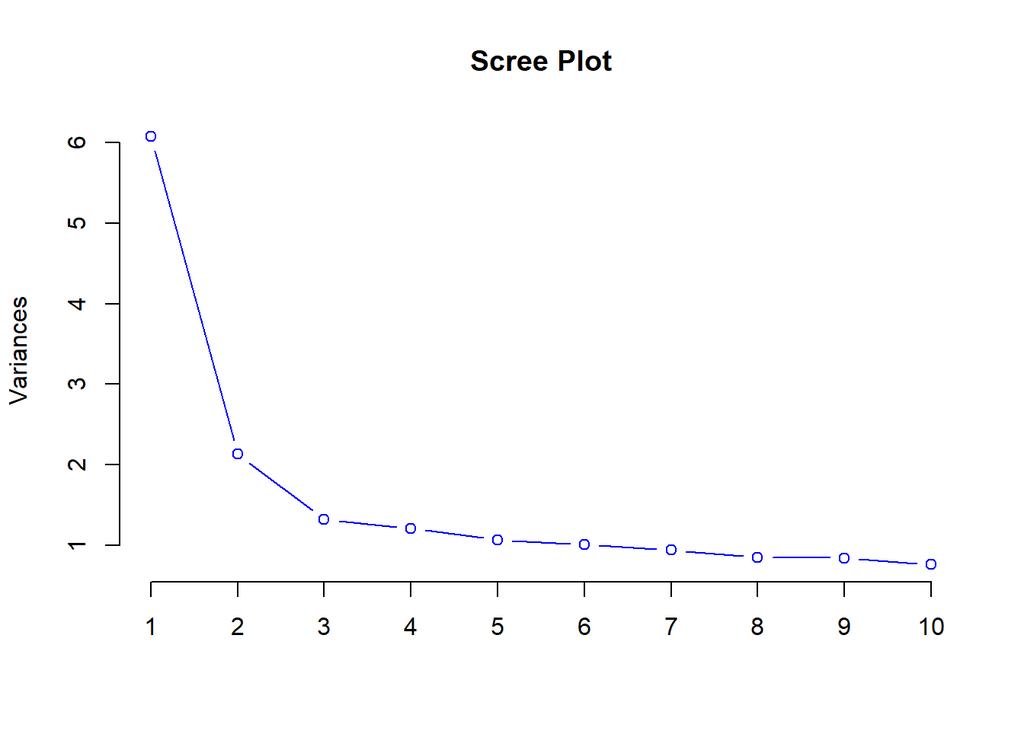

```r
screeplot(hp_pca, col = "blue", type = "lines", pch = 21, main="Scree Plot")
```

### 첫번째 축을 활용하여 병원 점수 구성하기

##### 점수의 평균은 100, 표준편차는 20이다.

```r
hp_pc1 <- predict(hp_pca)[,1] # 첫번째 축에 각 데이터를 정사영하여 병원점수를 구성한다.
hp_score <- (100-20*scale(hp_pc1))
hospital_score <- hpdata %>%
  select(dutyName.x,hpid)%>%
  mutate(score=hp_score)     # 병원이름, 병원ID, 병원점수를 선택하여 'hospital_score'라는 표를 만든다.
skim(hospital_score)
```

Data summary

| Name | hospital_score |
| --- | --- |
| Number of rows | 313 |
| Number of columns | 3 |
| _______________________ |  |
| Column type frequency: |  |
| character | 2 |
| numeric | 1 |
| ________________________ |  |
| Group variables | None |

**Variable type: character**

| skim_variable | n_missing | complete_rate | min | max | empty | n_unique | whitespace |
| --- | --- | --- | --- | --- | --- | --- | --- |
| dutyName.x | 0 | 1 | 3 | 23 | 0 | 312 | 0 |
| hpid | 0 | 1 | 8 | 8 | 0 | 313 | 0 |

**Variable type: numeric**

| skim_variable | n_missing | complete_rate | mean | sd | p0 | p25 | p50 | p75 | p100 | hist |
| --- | --- | --- | --- | --- | --- | --- | --- | --- | --- | --- |
| score | 0 | 1 | 100 | 20 | 67.9 | 84.92 | 92.55 | 110.11 | 164.63 | ▆▇▂▃▁ |

### 병원점수 시각화

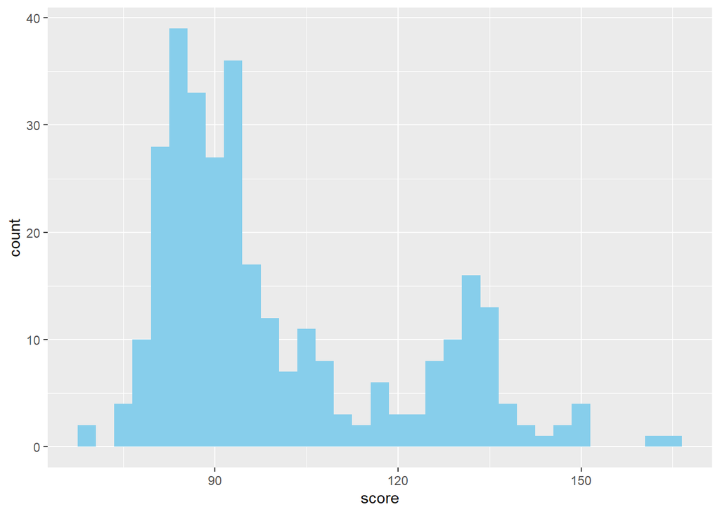

```r
library(ggplot2)
ggplot(hospital_score, aes(x=score))+
  geom_histogram(fill='sky blue', binwidth = 3)
```

### 병원점수 .csv 파일로 내보내기

```r
write.csv(hospital_score, file = 'hospital_score', row.names = FALSE)
```

```r
hp_score[hp_score > 112.5] %>% #상위 점수의 평균
  mean()
```

```
## [1] 131.7687
```

```r
hp_score[hp_score < 112.5] %>% #하위 점수의 평균
  mean()
```

```
## [1] 89.81257
```

# 3. 입력 변수에 따라 점수 만들기

### 소개

- 변수 입력에 따라 병원점수를 만들어주는 함수를 만들었다.

### 입력값

- c(“응급실”, “hv2”)와 같이 문자벡터를 입력해야 한다. 한글명과 영문명 모두 입력 가능하다.

### 함수 종류

- LetsMakeScore_Score - dplyr 패키지의 skim 함수를 통해 점수를 요약해준다.
- LetsMakeScore_Plot - histogram을 그려준다.
- LetsMakeScore_CSV - .csv 파일로 점수를 내보낸다. csv파일에서는 병원 이름과 병원 ID를 함께 확인할 수 있다.

### 사용할 수 있는 변수

| *한글명* | *영어명* |
| --- | --- |
| 내과중환자실 | hv2 |
| 외과중환자실 | hv3 |
| 신경외과중환자실 | hv6 |
| 응급실 | hvec |
| 입원실 | hvgc |
| 수술실 | hvoc |
| 소아 | hv10 |
| 인큐베이터 | hv11 |
| CT | hvctayn |
| MRI | hvmriayn |
| 인공호흡기 | hvventiayn |
| 뇌출혈수술 | mkioskty1 |
| 뇌경색수술 | mkioskty2 |
| 심근경색수술 | mkioskty3 |
| 복부손상수술 | mkioskty4 |
| 사지접합수술 | mkioskty5 |
| 응급내시경 | mkioskty6 |
| 응급투석 | mkioskty7 |
| 조산산모 | mkioskty8 |
| 신생아 | mkioskty10 |
| 중증화상 | mkioskty11 |

### 함수 사용 예시

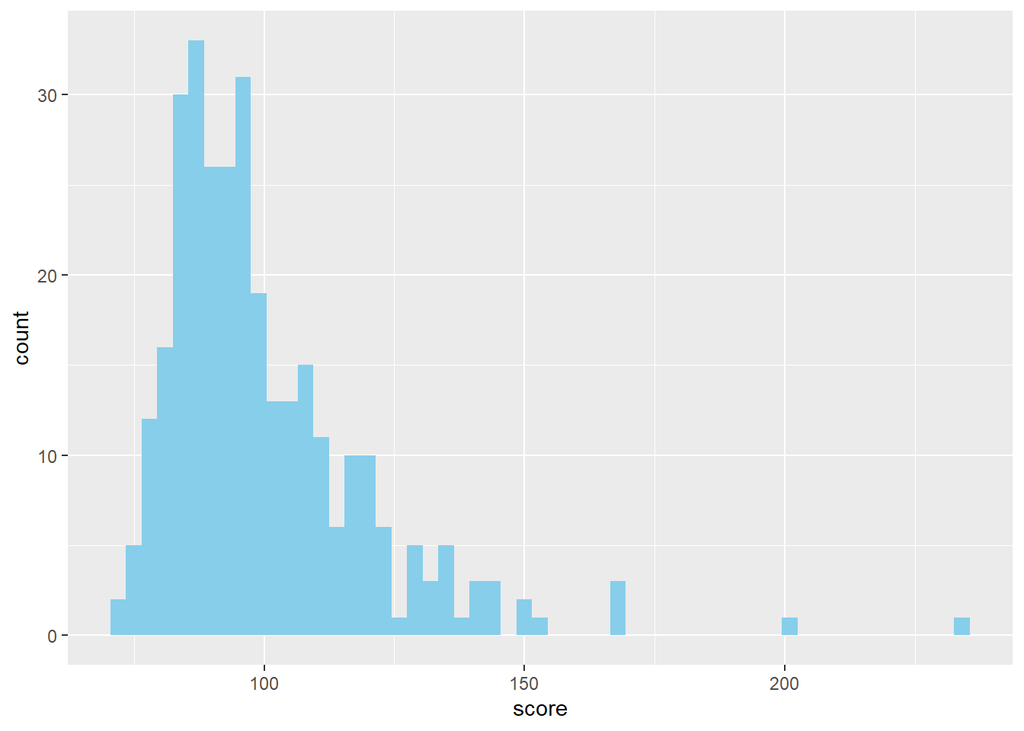

```r
LetsMakeScore_Plot(c("응급실","입원실","수술실"))
```

```r
#LetsMakeScore_Plot(c("CT","MRI","응급실", "수술실"))
```

```r
LetsMakeScore_Score(c("응급실","입원실","수술실"))
```

Data summary

| Name | Piped data |
| --- | --- |
| Number of rows | 313 |
| Number of columns | 1 |
| _______________________ |  |
| Column type frequency: |  |
| numeric | 1 |
| ________________________ |  |
| Group variables | None |

**Variable type: numeric**

| skim_variable | n_missing | complete_rate | mean | sd | p0 | p25 | p50 | p75 | p100 | hist |
| --- | --- | --- | --- | --- | --- | --- | --- | --- | --- | --- |
| score | 0 | 1 | 100 | 20 | 71.21 | 86.81 | 95.09 | 108.02 | 233.5 | ▇▃▁▁▁ |

```r
#LetsMakeScore_Score(c("CT","MRI","응급실", "수술실"))
```

```r
LetsMakeScore_CSV(c("응급실","입원실","수술실"))
#LetsMakeScore_CSV(c("CT","MRI","응급실", "수술실"))
```